# Deconvolution of Sanger Chromatograms to Quantify Resistance Mutations

Robert Morrison, LMIV/NIAID/NIH

Version 1.1, 12-Jan-2024; run on January 16, 2024 08:07 AM

### Chromatogram: LIB40115NdhfrForward_PREMIX_Plate_DNA_00017079_D10.ab1

### Gene of Interest: DHFR

You have selected the Sanger chromatogram file:  
~/Sanger.Deconvolution/Example.Data/DHFR_Data/LIB40115N/LIB40115NdhfrForward_PREMIX_Plate_DNA_00017079_D10.ab1

You have selected the Gene of Interest: DHFR

### Mutation Sites of Interest:

This `Sanger.Deconvolution.Rmd` script is configured to inspect DHFR at 7 mutation sites of interest:

Mutation Sites for DHFR

| Mutation.Name | Mutation.Motif | Reference.AA |
| --- | --- | --- |
| A16V | IYAICACCKVE | A |
| C50R | VLPWKCNSLDM | C |
| N51I | LPWKCNSLDMK | N |
| C59R | DMKYFCAVTTY | C |
| S108N | VMGRTSWESIP | S |
| V140L | DFDEDVYIINK | V |
| I164L | YKCFIIGGSVV | I |

## Deconvolution Methods

Each of the above mutation sites of interest will be investigated by a 3-step process:

1. Search for the 11aa mutation motif in all 6 possible reading frames of the chromatogram, to find the correct strand orientation and coding reading frame to align the chromatogram with the gene’s protein coding sequence. This step must be tolerant of both chromatogram noise and field isolate variation, so rather than expecting a perfect 11aa match, a similarity scoring method is used to find the one best matching location in all 6 reading frames. If no high scoring match is found, the deconvolution quantification fails for this motif.
2. Isolate the center 3-nucleotide codon region of the motif, to extract the tiny chromatogram fragment corresponding to the single amino acid of interest. This holds the raw trace matrix that describes the observed peak shapes and amplitudes in all 4 base call channels over the full period of 3 nucleotide peaks. As each peak shape is typically measured at about 10 data points per nucleotide, this tiny trace matrix will contain roughly 30 rows by 4 columns of raw intensity call values. This tiny extracted chromatogram trace matrix becomes the observed data for the final peak fitting step.
3. Perform the deconvolution. The observed tiny trace matrix is fitted by non-linear regression, using a simulated annealing algorithm (R package GenSA), as a weighted sum of all likely codons, where each possible codon is modeled as a tiny trace matrix of 3 gaussian peaks. The fitting process calculates the relative abundance of all model codon trace matrices that best fits the observed trace matrix. Lastly, each model codon of non-zero abundance is translated to its coding amino acid and proportionally summed, to give the final deconvolution result expressed as the relative proportions of one or more amino acids that best describe the observed chromatogram at that protein mutation site.

## Plots of Deconvolution Results

Below are visual images for each mutation motif search result, with the center codon highlighted and deconvoluted amino acid proportion results annotated above the codon.

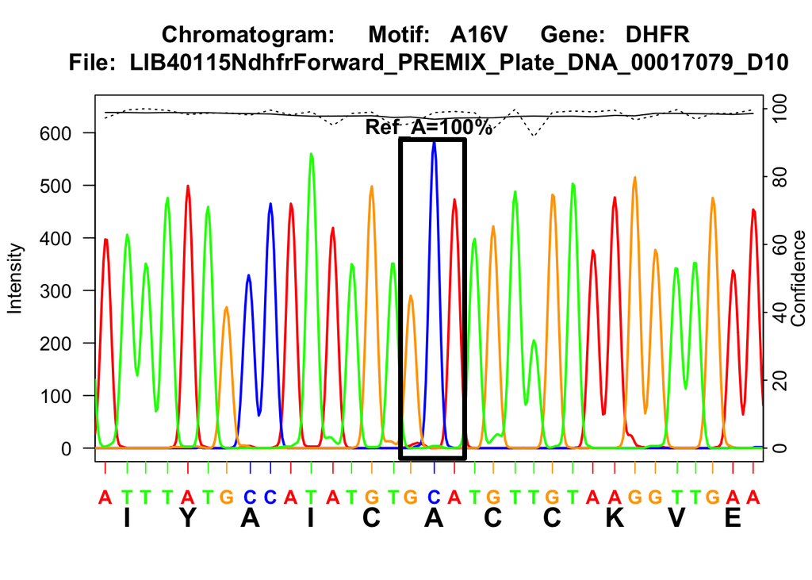

```
##
## Calling GenSA fit on:  A16V   value: 57598496
## value: 100116704
```

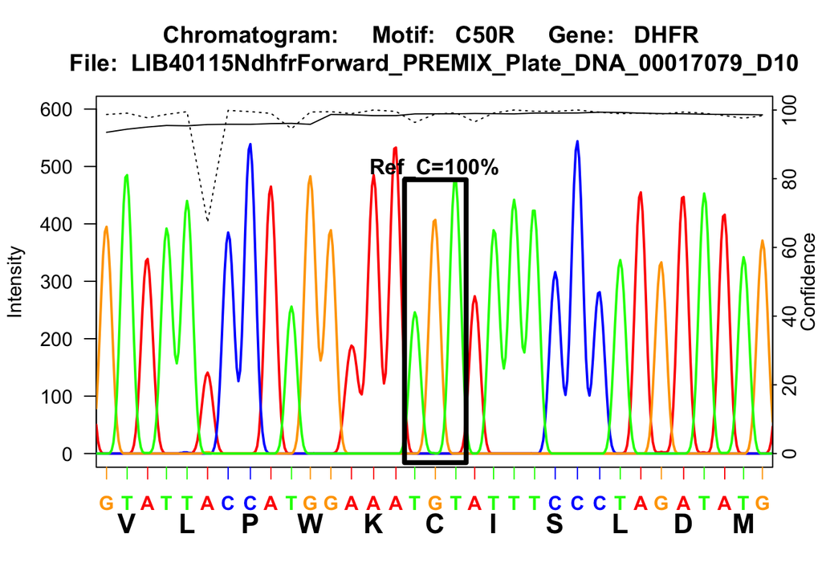

```
##
## Calling GenSA fit on:  C50R   value: 1421218024
```

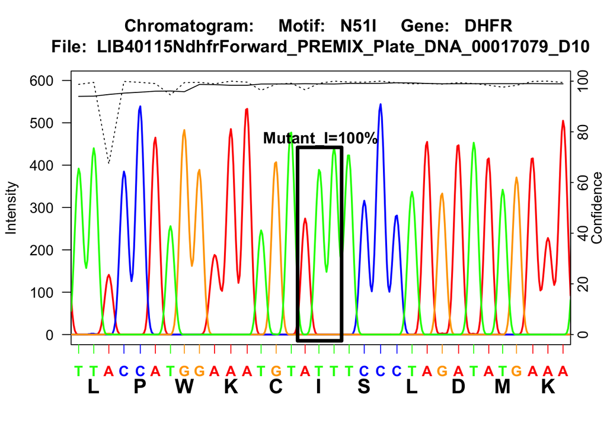

```
##
## Calling GenSA fit on:  N51I   value: -256148624
```

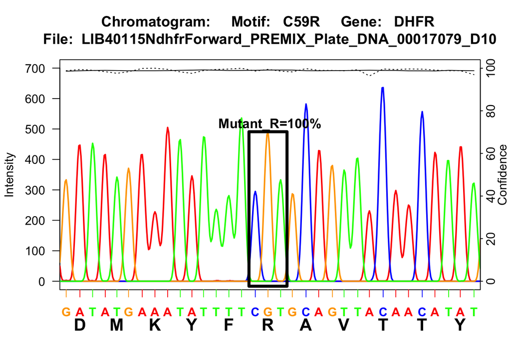

```
##
## Calling GenSA fit on:  C59R   value: -4385221
## value: 0
```

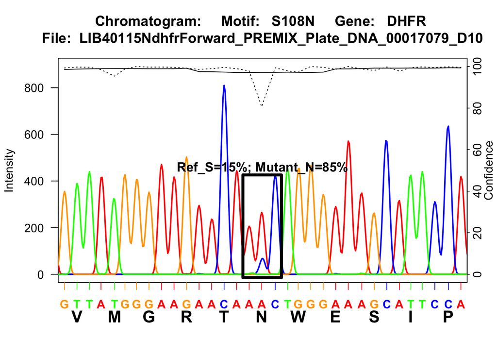

```
##
## Calling GenSA fit on:  S108N   value: -2119160495
## value: -502479714
```

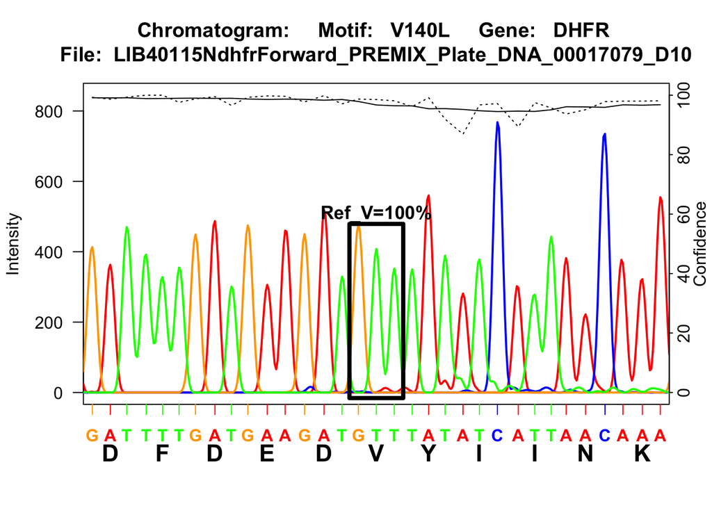

```
##
## Calling GenSA fit on:  V140L   value: 1
## value: 0
```

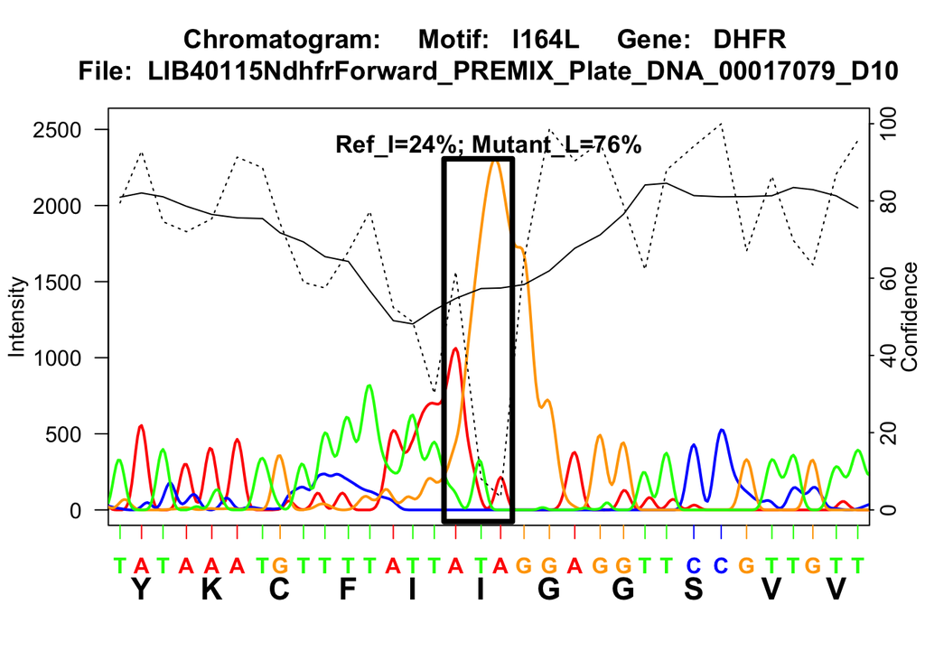

```
##
## Calling GenSA fit on:  I164L   value: 686999892
## value: 0
```

## Table of Deconvolution Results

This table of results has been written to CSV file: LIB40115N.LIB40115NdhfrForward_PREMIX_Plate_DNA_00017079_D10.Results.DHFR.csv

Motif Search and Model Fit Results: DHFR

| Motif | Status | Best_AA_Call | Best_Codon | Best_Percent | Ref_Name | Ref_Percent | Mutant_Name | Mutant_Percent | Confidence | AB1.File |
| --- | --- | --- | --- | --- | --- | --- | --- | --- | --- | --- |
| A16V | Pass | A | GCA | 100 | Ref_A | 100 |  | 0 | 98.14 | LIB40115NdhfrForward_PREMIX_Plate_DNA_00017079_D10.ab1 |
| C50R | Pass | C | TGT | 100 | Ref_C | 100 |  | 0 | 98.88 | LIB40115NdhfrForward_PREMIX_Plate_DNA_00017079_D10.ab1 |
| N51I | Pass | I | ATT | 100 |  | 0 | Mutant_I | 100 | 99.25 | LIB40115NdhfrForward_PREMIX_Plate_DNA_00017079_D10.ab1 |
| C59R | Pass | R | CGT | 100 |  | 0 | Mutant_R | 100 | 99.44 | LIB40115NdhfrForward_PREMIX_Plate_DNA_00017079_D10.ab1 |
| S108N | Pass | N | AAC | 85 | Ref_S | 15 | Mutant_N | 85 | 92.72 | LIB40115NdhfrForward_PREMIX_Plate_DNA_00017079_D10.ab1 |
| V140L | Pass | V | GTT | 100 | Ref_V | 100 |  | 0 | 98.87 | LIB40115NdhfrForward_PREMIX_Plate_DNA_00017079_D10.ab1 |
| I164L | Pass | L | TTG | 76 | Ref_I | 24 | Mutant_L | 76 | 26.93 | LIB40115NdhfrForward_PREMIX_Plate_DNA_00017079_D10.ab1 |

### Done with DHFR for LIB40115NdhfrForward_PREMIX_Plate_DNA_00017079_D10.ab1